# Introduction

La réussite scolaire en mathématiques constitue un véritable enjeu dans le système éducatif. En effet, les mathématiques se révèlent être une matière déterminante, tant pour la poursuite d’études que pour l’insertion professionnelle. Les compétences associées à cette discipline sont fortement mobilisées dans de nombreux domaines académiques et métiers.

Dans ce contexte, comprendre les éléments clés de la réussite en mathématiques permet d’identifier les facteurs susceptibles de contribuer à l’amélioration des performances des élèves et à la réduction des inégalités dans le cadre scolaire. Notre analyse vise ainsi à mettre en évidence et à hiérarchiser les principaux facteurs influençant la réussite scolaire en mathématiques.

Pour répondre à cette problématique, nous avons recueilli une base de données provenant de deux lycées portugais contenant plusieurs variables concernant leurs élèves. Nous présenterons nos résultats selon une approche par critères d’influence, regroupant les facteurs familiaux, scolaires et individuels.

# Les facteurs familiaux

## Le niveau d’éducation des parents

La distribution des notes des élèves est un indicateur essentiel pour observer les tendances globales des résultats scolaires. Parmis, ces notes nous pouvons voir une certaine hétérogénéité et ce que nous allons chercher à expliquer.

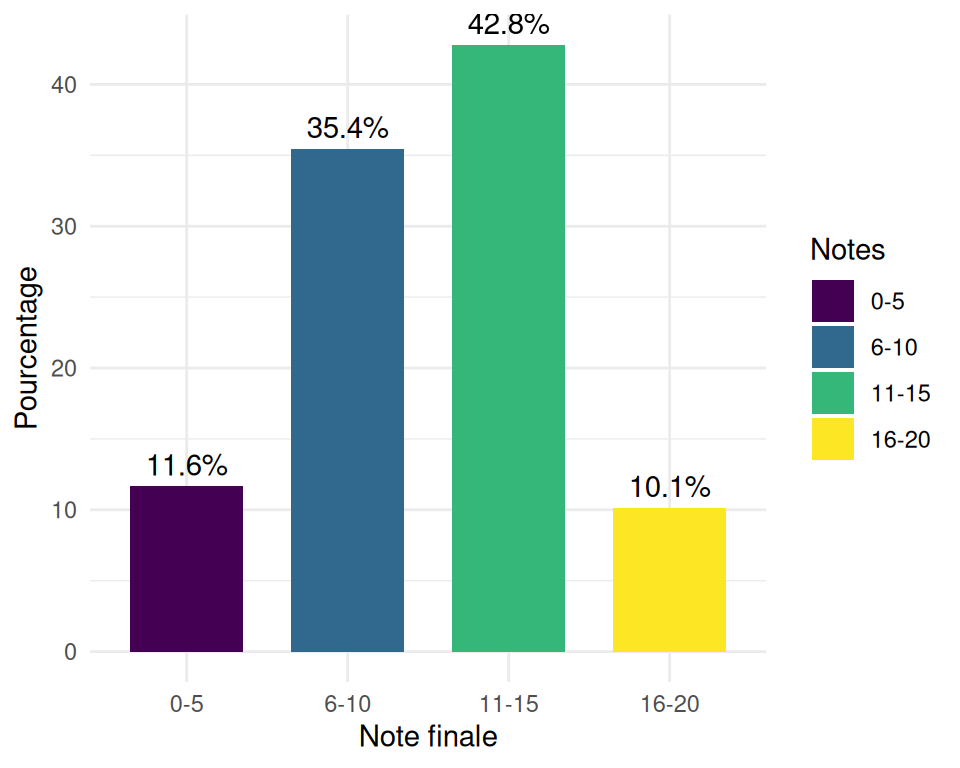

Dans le cadre scolaire, l’habitus se manifeste à travers la manière dont un élève se comporte en classe, la façon dont il aborde les apprentissages, ou encore ses attentes vis-à-vis de son avenir. Les élèves issus de milieux sociaux favorisés disposent souvent d’un habitus qui valorise l’éducation et les connaissances, ce qui les prépare mieux à réussir dans un système scolaire. À l’inverse, ceux issus de milieux plus modestes peuvent être confrontés à un habitus qui les conduit à percevoir l’école comme peu pertinent.

Ce mécanisme contribue donc à reproduire les inégalités sociales, car il crée des différences dans la manière d’aborder les savoirs et les attentes vis-à-vis de l’éducation. Ainsi, l’habitus influence de manière décisive les performances scolaires et, à terme, l’avenir des élèves. Dans les deux graphiques suivants, nous avons donc cette tendance mise en évidence. Que ce soit le niveau d’éducation du père ou de la mère, il impacte fortement la réussite des lycéens. Néanmoins, on observe que l’éducation de la mère semble avoir un impact plus marqué sur les résultats. Cela peut être lié au rôle plus central souvent attribué aux mères dans l’éducation et l’accompagnement scolaire. En revanche, l’éducation du père ne semble pas exercer la même pression sur les élèves, ce qui pourrait refléter des attentes sociales moins marquées vis-à-vis de l’implication paternelle dans l’éducation académique.

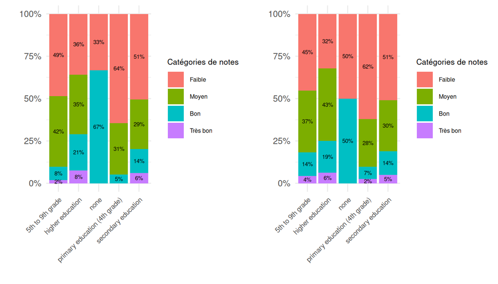

Répartition des notes par niveau d’éducation des parents\ : 64% des lycéens ayant une mère avec un niveau d’éducation très faible (4th) obtiennent de faibles résultats. 62% des lycéens ayant un père avec un niveau d’éducation très faible (4th) obtiennent de faibles résultats.

## Les métiers de la mère

Le métier de la mère joue un rôle significatif dans la réussite scolaire de ses enfants. Il influence non seulement les ressources matérielles disponibles pour l’élève, mais aussi les attentes vis-à-vis de l’éducation et la manière dont cette dernière est perçue dans le foyer.

Ainsi, les mères exerçant des professions qualifiées ont tendance à valoriser l’éducation de manière plus marquée et à inculquer à leurs enfants l’importance de la réussite scolaire. Ces élèves bénéficient souvent d’un environnement familial où l’éducation et la culture sont des priorités, avec un accompagnement scolaire plus soutenu. De plus, elles peuvent avoir davantage de ressources et de compétences pour soutenir leurs enfants dans leurs études, notamment en matière d’organisation, de gestion du temps ou de compréhension des matières enseignées.

À l’opposé, les élèves dont la mère occupe un emploi moins qualifié peuvent faire face à des attentes moins élevées concernant la réussite scolaire. Ces élèves peuvent aussi être moins soutenus dans leurs études. De plus, l’éloignement des milieux professionnels intellectuellement stimulants peut limiter les opportunités d’enrichissement personnel, comme les discussions culturelles ou les échanges d’idées.

Le graphique suivant montre cette tendance : nous observons que les élèves dont la mère exerce une profession plus qualifiée ou intellectuellement valorisée tendent à avoir de meilleurs résultats scolaires en mathématiques. En revanche, les élèves issus de familles où la mère exerce un emploi peu qualifié ou sans emploi semblent afficher des résultats scolaires plus faibles. Ce constat met en évidence l’importance du métier de la mère comme facteur déterminant de la réussite.

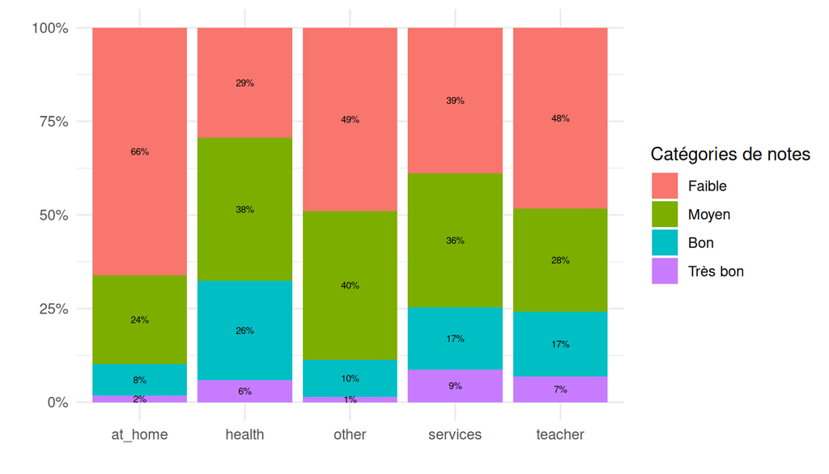

Répartition des notes par profession de la mère.\ : 6% des lycéens ayant une mère travaillant dans le domaine de la santé ont de très bonnes notes.

## Le type d’adresse

D’autre part, le lieu de résidence, qu’il soit rural ou urbain, joue un rôle dans la réussite scolaire des élèves. Ce facteur influence l’accès à des ressources éducatives et culturelles. Les élèves vivant en milieu urbain bénéficient généralement d’un accès plus facile aux infrastructures scolaires, aux activités périscolaires, ainsi qu’à des ressources culturelles et éducatives variées, telles que des bibliothèques, des musées ou des événements éducatifs. Ces éléments contribuent à créer un environnement propice à la réussite scolaire.

À l’inverse, les élèves résidant dans des zones rurales peuvent rencontrer plusieurs obstacles à leur réussite scolaire. L’accès à des établissements scolaires de qualité peut être limité, et les options éducatives, comme les spécialités ou les activités extra-scolaires, sont souvent moins diversifiées. Le graphique ci-dessou nous montre bien ce phénomène.

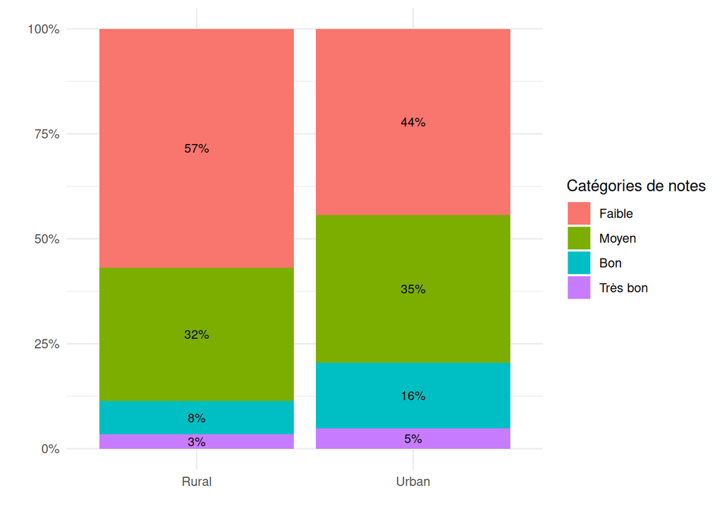

Répartition des notes par type d’adresse.\ : 5% des élèves provenant d’un milieu urbain ont de très bons résultats.

De plus, la distance géographique à parcourir pour rejoindre un établissement scolaire peut rendre l’organisation de la journée scolaire plus difficile et fatigante, c’est ce que nous pouvons observer dans le graphique suivant.

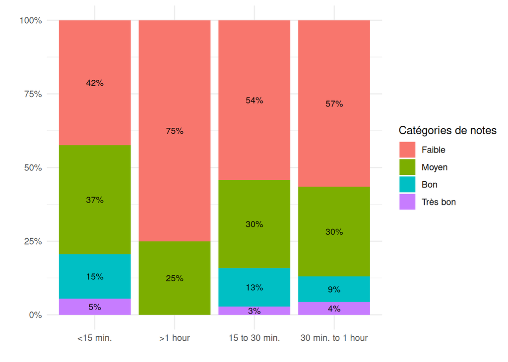

Répartition des notes par temps de trajet.\ : 0% des lycéens ont de bonnes notes pour les trajets de plus d’une heure.

# Les facteurs scolaires

## Le soutien scolaire

Le soutien scolaire est souvent perçu comme un levier pour améliorer les performances des élèves, en particulier ceux qui rencontrent des difficultés. Toutefois, bien que le soutien scolaire soit censé aider les élèves à mieux comprendre les matières et à combler leurs lacunes, nous remarquons dans les graphiques ci-dessous que les élèves bénéficiant de ce soutien semblent avoir davantage de notes faibles.

Ainsi, il est possible que les élèves qui sollicitent un soutien scolaire soient déjà confrontés à des difficultés importantes, ce qui pourrait rendre plus difficile la remontée de leurs résultats malgré l’accompagnement. Même si, le soutien scolaire apparaît comme un moyen d’améliorer la réussite des élèves, il est possible qu’il ne soit pas toujours une solution suffisante ou appropriée pour certains élèves. Les graphiques ci-dessous illustrent cette tendance, avec une concentration plus importante de notes faibles parmi les élèves ayant reçu un soutien scolaire. Cela met en évidence la nécessité d’adapter les dispositifs de soutien scolaire pour qu’ils puissent répondre aux divers besoins des élèves.

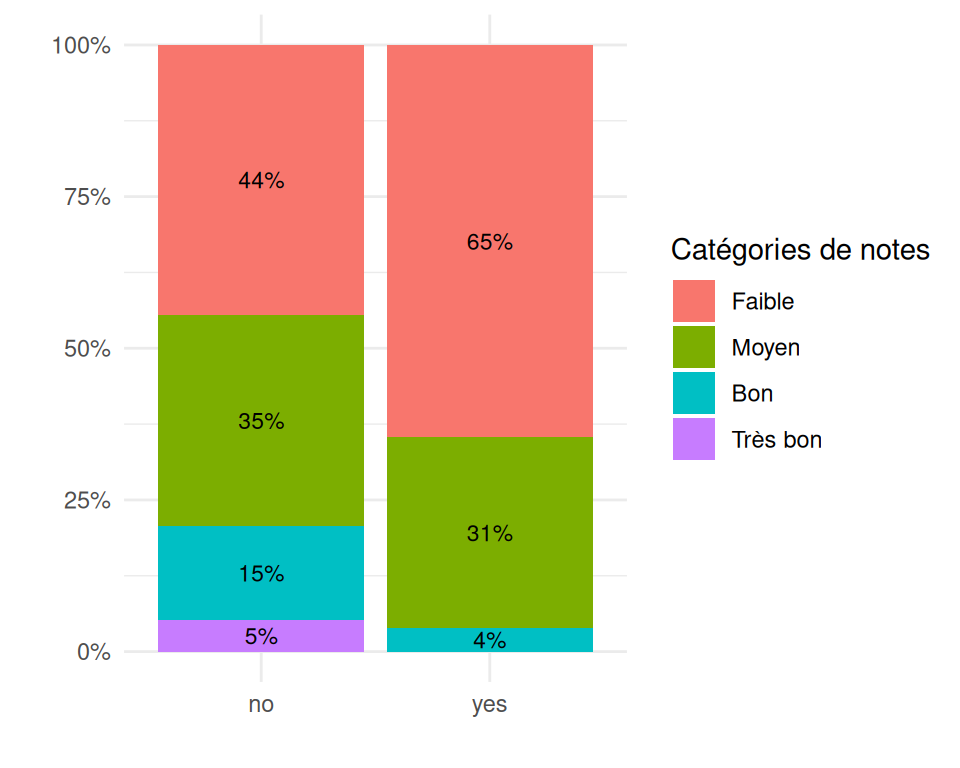

Répartition des notes par soutien scolaire.\ : 4% des lycéens ayant du soutien scolaire ont de bonnes notes.

# Le Temps d’étude : Un Facteur Non-Significatif Révélant le Paradoxe de la Quantité versus la Qualité

## Le temps d’étude

Le temps libre disponible pour les adolescents joue un rôle crucial et contre-intuitif dans leur parcours scolaire. Il influence non seulement la capacité de récupération cognitive nécessaire aux apprentissages, mais aussi les dynamiques attentionnelles et la manière dont l’effort académique est géré dans le temps.

Ainsi, les adolescents disposant d’un temps libre faible mais structuré ont tendance à optimiser leur gestion temporelle et à développer une discipline académique rigoureuse. Ces élèves bénéficient souvent d’un cadre contraint qui force la priorisation : confrontés à un temps libre limité, ils doivent choisir stratégiquement entre repos, loisirs et études, ce qui génère une efficacité accrue dans l’utilisation de chaque plage horaire. De plus, la rareté du temps libre crée un effet de valorisation : chaque moment libre devient précieux et est utilisé de manière plus intentionnelle, évitant la procrastination et les distractions passives. Cette contrainte temporelle modérée produit également un équilibre entre stimulation cognitive et récupération, permettant aux élèves de maintenir une concentration soutenue sans basculer dans l’épuisement.

À l’opposé, les élèves disposant de très peu de temps libre peuvent faire face à une surcharge cognitive chronique et un épuisement mental progressif. Ces élèves peuvent aussi être exposés à un stress permanent lié à l’impossibilité de récupérer mentalement, ce qui dégrade leurs capacités attentionnelles et mnésiques. L’absence de moments de repos et de loisirs limite les opportunités de consolidation mémorielle (le cerveau a besoin de pauses pour intégrer les apprentissages) et peut générer un syndrome de burnout précoce. De plus, l’absence totale de temps libre prive l’adolescent d’expériences sociales et ludiques essentielles à son développement émotionnel, créant un déséquilibre psychologique qui se répercute négativement sur les performances académiques.

Inversement, les élèves disposant de beaucoup ou énormément de temps libre peuvent faire face à un paradoxe de la liberté temporelle : trop de temps disponible génère de la procrastination, de la dispersion attentionnelle et une perte de structure. Ces élèves peuvent aussi être exposés à des distractions chroniques (réseaux sociaux, jeux vidéo, télévision) qui consomment massivement leur temps sans valeur académique ajoutée. L’abondance de temps libre peut également signaler des situations familiales précaires (parents absents, manque d’encadrement) ou un désengagement scolaire préalable (élèves déjà en difficulté qui “ont abandonné”). De plus, l’hyper-disponibilité temporelle réduit la nécessité de planification et d’autodiscipline, compétences pourtant cruciales pour la réussite académique.

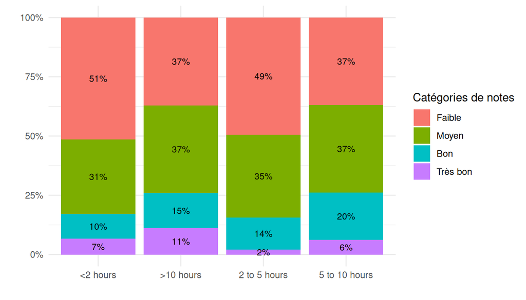

Répartition des notes par temps d’étude.\ : 37% des lycéens ayant plus de 10 heures de temps d’étude ont des notes faibles.

# Les facteurs individuels

## L’Âge : Un Facteur Significatif Révélant les Mécanismes de Sélection Académique Progressive

L’âge des élèves a une influence importante sur leur réussite en mathématiques, car il reflète souvent leur parcours scolaire passé. Les élèves les plus jeunes au lycée ont généralement suivi une scolarité régulière, sans redoublement. Cela indique qu’ils ont acquis les bases nécessaires au bon moment et qu’ils arrivent au lycée avec de bonnes habitudes de travail, une motivation stable et un lien positif avec l’école. Ils bénéficient aussi, dans de nombreux cas, d’un environnement familial favorable qui soutient les apprentissages.

À contrario, les élèves plus âgés dans le système scolaire ont souvent connu des difficultés comme des redoublements ou des interruptions de scolarité. Ces parcours plus compliqués peuvent entraîner un manque de confiance en soi, une fatigue scolaire et un sentiment de décalage par rapport aux autres élèves. Avec le temps, ces difficultés s’accumulent et rendent la réussite en mathématiques de plus en plus difficile.

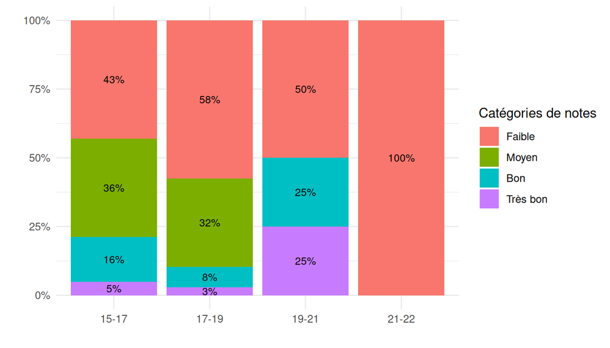

Répartition des notes par catégories d’âge.\ : 50% des élèves entre 19 et 21 ans obtiennent des notes très faibles.

## Le temps libre : Un Facteur Significatif attestant la Théorie de l’Équilibre Cognitif Optimal

Le temps libre disponible pour les adolescents joue un rôle crucial et contre-intuitif dans leur parcours scolaire. Il influence non seulement la capacité de récupération cognitive nécessaire aux apprentissages, mais aussi les dynamiques attentionnelles et la manière dont l’effort académique est géré dans le temps.

Ainsi, les adolescents disposant d’un temps libre faible mais structuré ont tendance à optimiser leur gestion temporelle et à développer une discipline académique rigoureuse. Ces élèves bénéficient souvent d’un cadre contraint qui force la priorisation : confrontés à un temps libre limité, ils doivent choisir stratégiquement entre repos, loisirs et études, ce qui génère une efficacité accrue dans l’utilisation de chaque plage horaire. De plus, la rareté du temps libre crée un effet de valorisation : chaque moment libre devient précieux et est utilisé de manière plus intentionnelle, évitant la procrastination et les distractions passives. Cette contrainte temporelle modérée produit également un équilibre entre stimulation cognitive et récupération, permettant aux élèves de maintenir une concentration soutenue sans basculer dans l’épuisement.

À l’antipode, les élèves disposant de très peu de temps libre peuvent faire face à une surcharge cognitive chronique et un épuisement mental progressif. Ces élèves peuvent aussi être exposés à un stress permanent lié à l’impossibilité de récupérer mentalement, ce qui dégrade leurs capacités attentionnelles et mnésiques. L’absence de moments de repos et de loisirs limite les opportunités de consolidation mémorielle (le cerveau a besoin de pauses pour intégrer les apprentissages) et peut générer un syndrome de burnout précoce. De plus, l’absence totale de temps libre prive l’adolescent d’expériences sociales et ludiques essentielles à son développement émotionnel, créant un déséquilibre psychologique qui se répercute négativement sur les performances académiques.

Réciproquement, les élèves disposant de beaucoup ou énormément de temps libre peuvent faire face à un paradoxe de la liberté temporelle : trop de temps disponible génère de la procrastination, de la dispersion attentionnelle et une perte de structure. Ces élèves peuvent aussi être exposés à des distractions chroniques (réseaux sociaux, jeux vidéo, télévision) qui consomment massivement leur temps sans valeur académique ajoutée. L’abondance de temps libre peut également signaler des situations familiales précaires (parents absents, manque d’encadrement) ou un désengagement scolaire préalable (élèves déjà en difficulté qui “ont abandonné”). De plus, l’hyper-disponibilité temporelle réduit la nécessité de planification et d’autodiscipline, compétences pourtant cruciales pour la réussite académique.

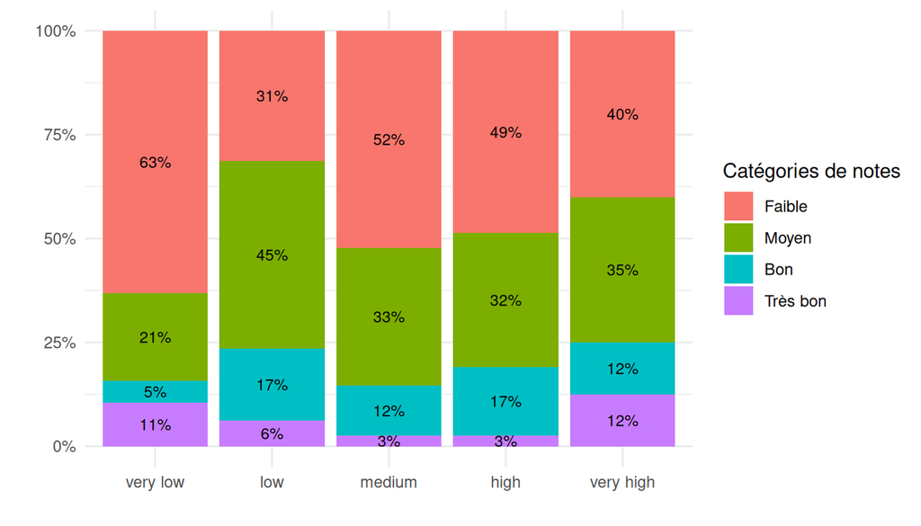

Répartition des notes par temps libre disponible.\ : 63% des lycéens ayant très peu de temps libre ont de faibles résultats.

## Le Niveau d’Activités Sociales : Un Facteur Non-Significatif divulguant une Relation Dose-Dépendante Négative

Les résultats mettent en évidence une relation négative et non linéaire entre le niveau de socialisation des adolescents et leurs performances scolaires, en particulier en mathématiques.

Conformément au Time Budget Model (Becker, 1965), le temps constitue une ressource limitée : toute augmentation du temps consacré aux activités sociales se fait mécaniquement au détriment du temps d’étude. Le graphique illustre clairement cette dynamique progressive.

Au-delà de la contrainte temporelle, les normes de groupe jouent un rôle central (Ryan, 2001) : dans certains contextes adolescents, la sociabilité est davantage valorisée que la réussite académique, conduisant à un ajustement des performances. Par ailleurs, l’intensité des interactions sociales génère une fatigue cognitive et émotionnelle (Lieberman, 2013), réduisant la capacité de concentration. L’ensemble de ces éléments révèle une relation dose-dépendante négative : si la socialisation est développementalement normale, son intensification excessive entre en concurrence directe avec l’investissement académique requis pour exceller en mathématiques, c’est donc ce schéma directeur que nous relaie le graphique qui suit :

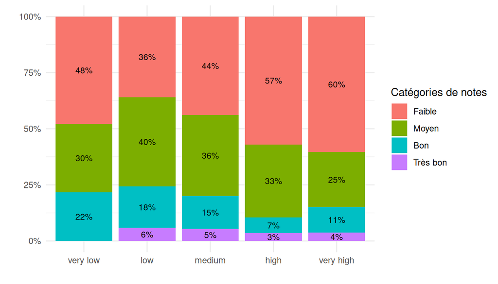

Répartition des notes par niveau d’activités sociales.\ : 22% ayant très peu d’activités sociales obtiennent de bonnes notes.

## Les relations amoureuses

L’engagement dans une relation amoureuse à l’adolescence joue un rôle complexe dans le parcours scolaire des lycéens. Il influence non seulement la répartition des ressources temporelles et cognitives disponibles pour l’élève, mais aussi les priorités existentielles et la manière dont l’excellence académique est perçue durant cette période développementale critique.

Ainsi, les adolescents engagés dans une relation amoureuse tendent à réallouer une partie substantielle de leur temps et de leur énergie mentale vers la gestion de cette relation. Ces élèves consacrent quotidiennement plusieurs heures aux communications affectives (messages, appels, rencontres), aux préoccupations émotionnelles (jalousie, tensions, réconciliations) et à la construction identitaire relationnelle. Cette mobilisation permanente des ressources cognitives entre en concurrence directe avec l’investissement académique requis pour atteindre l’excellence en mathématiques. De plus, les adolescents en relation peuvent bénéficier d’un soutien émotionnel stabilisateur, mais subissent également une volatilité affective (disputes, ruptures potentielles) qui fragmente leur capacité de concentration soutenue.

À l’opposé, les élèves sans engagement amoureux disposent d’une liberté attentionnelle maximale pour se consacrer exclusivement aux apprentissages académiques. Ces élèves peuvent aussi être moins exposés aux distractions émotionnelles chroniques qui caractérisent les relations adolescentes. De plus, l’absence de relation amoureuse leur permet de maintenir une flexibilité temporelle optimale pour l’étude intensive, notamment en matière d’organisation des révisions, de participation à des activités périscolaires enrichissantes ou de consolidation des apprentissages complexes.

Le graphique suivant montre cette tendance : nous observons que les élèves sans relation amoureuse tendent à atteindre plus fréquemment les niveaux d’excellence académique en mathématiques, avec une proportion significativement plus élevée de résultats “Très bon”. En revanche, les élèves engagés dans une relation amoureuse semblent se concentrer davantage dans les catégories de résultats “Moyen” et “Bon”, avec une quasi-absence d’accès à l’excellence. Ce constat met en évidence l’importance de l’allocation des ressources cognitives et temporelles comme facteur déterminant de la réussite scolaire, et révèle que l’engagement amoureux adolescent, bien que normal et sain sur le plan développemental, exerce un effet de plafonnement sur les performances académiques maximales.

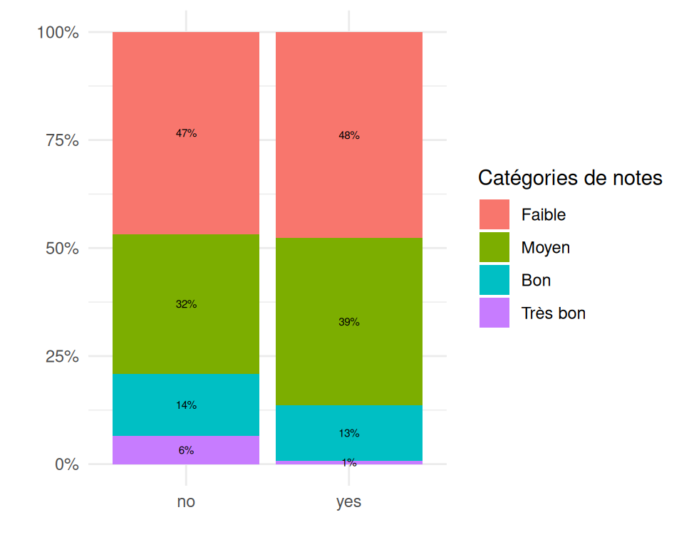

Répartition des notes par engagement dans une relation amoureuse.\ : 1% des lycéens ayant une relation amoureuse ont de très bonnes notes.

# Conclusion

L’analyse des performances en mathématiques des élèves portugais met en évidence le caractère multifactoriel et non mécanique de la réussite scolaire. Les résultats suggèrent que la performance ne dépend ni exclusivement de la quantité de travail fourni, ni d’un facteur individuel isolé, mais de l’interaction entre trajectoires scolaires, stratégies d’apprentissage, environnement familial et contexte social.

Les variables comportementales et sociales (socialisation, gestion du temps, relations affectives) exercent des effets indirects via l’allocation des ressources cognitives, tandis que l’âge agit principalement comme un proxy de parcours scolaires cumulativement défavorables, et non comme une cause directe de l’échec. Par ailleurs, la non-significativité ou la non-linéarité de certaines variables quantitatives (temps d’étude, temps libre) confirme que l’efficacité des apprentissages prévaut sur leur intensité.

Ces constats rejoignent la littérature internationale, qui souligne le rôle central du capital culturel familial, des compétences métacognitives et de la structuration des environnements d’apprentissage. En conséquence, les politiques éducatives visant l’amélioration des performances en mathématiques doivent dépasser une logique purement méritocratique et quantitative, pour privilégier des approches intégrées combinant soutien pédagogique, accompagnement social et différenciation des parcours scolaires. …

# Remerciements

Nous remercions M. Regnault pour ses conseils avisés et son accompagnement tout au long de ce projet.

# Annexes

## Préparation des données

```r
epu_data <- data %>%
  select(-student_id) %>%
  rename(school_choice = school_choice_reason,
         extra_classes = extra_paid_classes)

# Catégories de notes
epu_data <- epu_data %>%
  mutate(grade_cat = cut(as.numeric(final_grade),
                         breaks = c(0, 10, 14, 17, 20),
                         labels = c("Faible", "Moyen", "Bon", "Très bon"),
                         include.lowest = TRUE))

# Catégories d'âge
epu_data <- epu_data %>%
  mutate(age_cat = cut(as.numeric(age),
                       breaks = c(15, 17, 19, 21, 22),
                       labels = c("15-17", "17-19", "19-21", "21-22"),
                       include.lowest = TRUE))

# Catégories de qualité des relations familiales
epu_data <- epu_data %>% mutate(
  family_cat = factor(family_relationship,
                      levels = 1:5,
                      labels = c("very bad", "bad", "neutral",
                                 "good", "very good"),
                      ordered = TRUE))

# Catégories de temps libre
epu_data <- epu_data %>% mutate(free_time_cat = factor(free_time,
                                                       levels = 1:5,
                                                       labels = c("very low",
                                                                  "low",
                                                                  "medium",
                                                                  "high",
                                                                  "very high"),
                                                       ordered = TRUE))

# Catégories de niveau d'activités sociales
epu_data <- epu_data %>% mutate(social_cat = factor(social,
                                                    levels = 1:5,
                                                    labels = c("very low",
                                                               "low",
                                                               "medium",
                                                               "high",
                                                               "very high"),
                                                    ordered = TRUE))

# Catégories de consommation d'alcool la semaine
epu_data <- epu_data %>% mutate(weekday_alcohol_cat = factor(weekday_alcohol,
                                                             levels = 1:5,
                                                             labels = c(
                                                               "very low",
                                                               "low",
                                                               "medium",
                                                               "high",
                                                               "very high"),
                                                             ordered = TRUE))

# Catégories de consommation d'alcool le weekend
epu_data <- epu_data %>% mutate(weekend_alcohol_cat = factor(weekend_alcohol,
                                                             levels = 1:5,
                                                             labels = c(
                                                               "very low",
                                                               "low",
                                                               "medium",
                                                               "high",
                                                               "very high"),
                                                             ordered = TRUE))

# Catégories d'état de santé
epu_data <- epu_data %>% mutate(health_cat = factor(health,
                                                    levels = 1:5,
                                                    labels = c("very bad",
                                                               "bad", "fair",
                                                               "good",
                                                               "very good"),
                                                    ordered = TRUE))

# Catégories d'absences
epu_data <- epu_data %>% mutate(absences_cat = cut(absences,
                                                   breaks = c(0, 5, 10, 20,
                                                              40, 75),
                                                   labels = c("0-5", "5-10",
                                                              "10-20",
                                                              "20-40", "40-75"),
                                                   include.lowest = TRUE))
```

## ACM (Analyse des Correspondances Multiples)

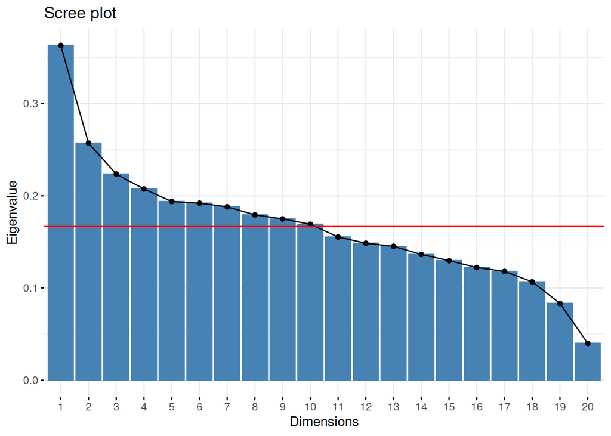

Graphique des valeurs propres

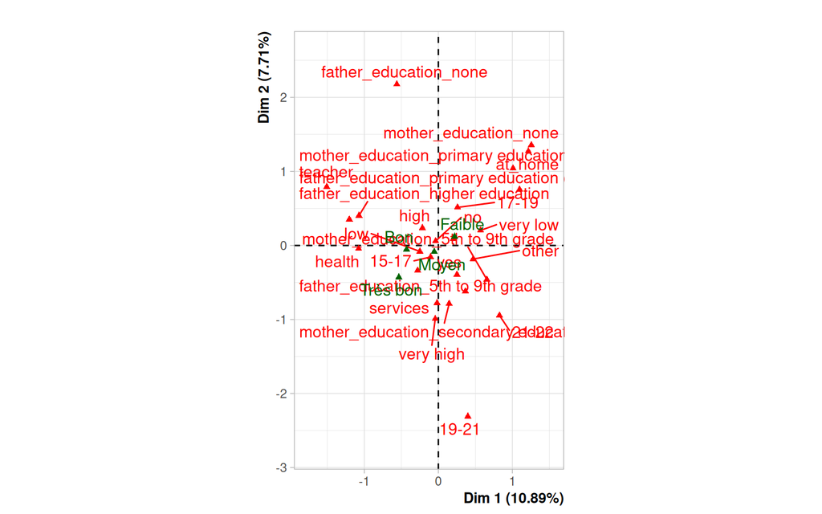

Graphique de l’ACM

Le premier axe oppose un niveau d’éducation faible des parents avec un niveau élevé. Ainsi, mother_education_primary, mother_education_higher, father_education_higher father_education_primary et teacher sont les modalités les plus contributives pour cet axe. Néanmoins, nous pouvons constater sur le graphique de l’ACM, que le niveau d’éducation faible est corrélé avec des résultats faibles des lycéens en Mathématiques. D’autre part, nous avons le niveau d’éducation élevé corrélé avec des résultats plus élevés (“bon”,“moyen”,“très bon”).

Le deuxième axe met en évidence l’opposition entre un niveau d’éducation secondaire des parents et d’emplois peu qualifiés de la mère avec un niveau faible d’éducation et le statut de femme au foyer de la mère. De plus, sur le graphique de l’ACM, nous pouvons constater que l’emploi de la mère et le niveau d’éducation des parents ont une influence sur la réussite scolaire. Ainsi, plus le niveau d’éducation est élevé et plus l’emploi est qualifié plus les élèves réussissent.

L’axe 3 distingue principalement les élèves de 19-21 ans, ceux ayant un père de niveau secondaire, ceux bénéficiant d’un soutien scolaire et ceux ayant un temps libre moyen ou très élevé. Ces facteurs contribuent à différencier certains profils d’élèves. Les autres modalités ne sont pas représentées de manière fiable sur cet axe, donc Dim 3 ne permet pas d’interpréter le “profil opposé” ou les élèves avec moins de réussite.

# Références bibliographiques

```
Bourdieu, P., & Passeron, J.-C. (1970).
La reproduction. Éléments pour une théorie du système d'enseignement.
Paris : Éditions de Minuit.
→ Preuve : ouvrage fondateur, cadre théorique majeur, abondamment validé empiriquement.

Lahire, B. (1995).
Tableaux de familles. Heurs et malheurs scolaires en milieux populaires.
Paris : Gallimard / Seuil.
→ Preuve : enquêtes qualitatives approfondies, forte validité empirique.

Becker, G. S. (1965).
A Theory of the Allocation of Time.
The Economic Journal, 75(299), 493–517.
→ Preuve : modèle microéconomique canonique, très largement cité.

Sweller, J. (1988).
Cognitive load during problem solving: Effects on learning.
Cognitive Science, 12(2), 257–285.
→ Preuve : résultats expérimentaux robustes, répliqués.

Csikszentmihalyi, M. (1990).
Flow: The Psychology of Optimal Experience.
New York : Harper & Row.
→ Preuve : cadre psychologique validé empiriquement, usage transversal.

Lareau, A. (2002).
Invisible Inequality: Social Class and Childrearing in Black Families and White Families.
American Sociological Review, 67(5), 747–776.
→ Limite : contexte américain spécifique.

Ryan, A. M. (2001).
The peer group as a context for the development of young adolescent motivation and achievement.
Child Development, 72(4), 1135–1150.
→ Limite : effets indirects, dépendants du contexte scolaire.

Becker, H. S. (1963).
Outsiders: Studies in the Sociology of Deviance.
New York : Free Press.
→ Limite : théorie générale du labeling, application scolaire indirecte.

OECD (2019).
PISA 2018 Results (Volume I): What Students Know and Can Do.
Paris : OECD Publishing.
→ Preuve : données comparatives standardisées, haute fiabilité.

Fernandes, D. (2004).
Avaliação das aprendizagens em matemática.
Lisbonne : Ministério da Educação.
→ Limite : diffusion principalement nationale.

Dupriez, V., & Dumay, X. (2006).
Inequalities in school systems: Effect of school structure or of society structure?
Comparative Education, 42(2), 243–260.
→ Preuve : analyse comparative robuste.
```